# Data Visualization Notes

Luis Moreno

12/27/2020

# Introduction to Tidyverse

The process of structuring datasets to facilitate analysis is called “data tidying” by Hadley Wickham.

Requisites to classify a dataset as tidy:

1. Each variable forms a column
2. Each observation forms a row
3. Each type of observational unit forms a table.

More information on tidy data can be found at:

```r
vignette("tidy-data")
```

To use the “tidyverse” commands the package must be installed first and then loaded with:

```r
library(tidyverse)
```

## Importing Data

### Read CSV

The difference between the base R read.csv and tidyverse read_csv is the output, this latter results in a “tibble” class object.

# R for Data Science

## 1. Introduction

**Figure 1**. Basic Data Science Cycle

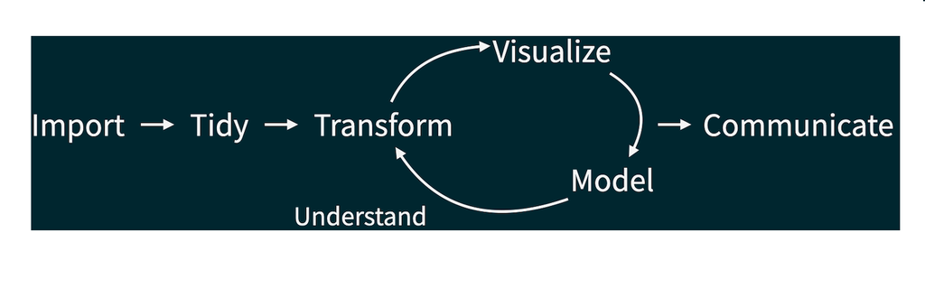

### Data Science Cycle

1. **Import data**  
   Take data stored on a file, database or API and load it into a data frame in R.
2. **Tidy data**  
   Store data in a consistent form. When data is tidy, each column is a variable and each row is an observation.
3. **Transform data**  
   Calculate new variables and summary statistics for observations of interest.
4. **Visualization**  
   Represent your data in a graphical way to understand your questions.
5. **Models**  
   It complements visualization and tries to answer questions.
6. **Communicate**  
   Share your results with others.
7. **Programming**  
   It is a cross-cutting tool that is used in every part of the project.

## Tibbles

A `tibble` is a specialized version of a data frame that is setup to work better with the tidyverse.

More information on “tibbles” can be found at:

```r
vignette("tibble")
```

To coerce a regular data frame into a tibble use:

```r
as_tibble(data-frame-name)
```

Create a new tibble from individual vectors

```r
tibble(
  names = c("Pedro", "Maria", "Natalia"),
  age = c(21, 34, 19),
  profession = c("Cashier", "Nurse", "Accountant")
)
```

```
## # A tibble: 3 x 3
##   names     age profession
##   <chr>   <dbl> <chr>
## 1 Pedro      21 Cashier
## 2 Maria      34 Nurse
## 3 Natalia    19 Accountant
```

Some properties of a `tibble`includes:  
- never changes the type of the inputs,  
- never changes the names of variables,  
- never creates row names.

Create a `tibble` by transposing its input with `tribble`. Consider that variable names start with `~` and entries are separated by commas.

```r
tribble(
  ~names, ~age, ~profession,
#  -----|-----|------------|
  "Pedro", 21, "Cashier",
  "Maria", 34, "Nurse",
  "Natalia", 19, "Accountant"
)
```

```
## # A tibble: 3 x 3
##   names     age profession
##   <chr>   <dbl> <chr>
## 1 Pedro      21 Cashier
## 2 Maria      34 Nurse
## 3 Natalia    19 Accountant
```

### `tibble` versus `data.frame`

#### Printing

- Tibbles show the first 10 rows and all the columns that fit on screen when printed. To show more results use the `print()`command and specify the number of rows with `n`and the `width`of the display (use Inf to show all columns).
- Use `View()`to navigate on large tibbles inside R.

#### Subsetting

- Extract a variable by name using `$`
- Extract a variable by name or position using `[[]]`.

```r
top_cartoons <- tibble(
  cartoon_name = c("Dexter´s Laboratory", "Rugrats", "Hey Arnold!"),
  release_year = c(1996, 1991, 1996)
)

# Extract variable by name
top_cartoons$cartoon_name
```

```
## [1] "Dexter´s Laboratory" "Rugrats"             "Hey Arnold!"
```

```r
top_cartoons[["cartoon_name"]]
```

```
## [1] "Dexter´s Laboratory" "Rugrats"             "Hey Arnold!"
```

```r
# Extract variable by position
top_cartoons[[1]]
```

```
## [1] "Dexter´s Laboratory" "Rugrats"             "Hey Arnold!"
```

Find the complete list of `tibble`settings with:

```r
package?tibble
```

## Functions Glossary

### Data Manipulation Functions

[read_csv()](https://www.rdocumentation.org/packages/readr/versions/1.3.1/topics/read_delim): reads a CSV file into R.  
[as.data.frame()](https://www.rdocumentation.org/packages/base/versions/3.6.2/topics/as.data.frame): check if an object is a data frame, or coerce it if possible.  
[as_tibble()](https://www.rdocumentation.org/packages/tibble/versions/3.0.4/topics/as_tibble): turns an existing object, into a so-called tibble, a data frame with class `tbl_df`.  
[drop_na()](https://www.rdocumentation.org/packages/tidyr/versions/0.8.3/topics/drop_na): drop rows containing missing values.  
[filter()](https://www.rdocumentation.org/packages/dplyr/versions/0.7.8/topics/filter): find rows/cases where conditions are true.  
[dim()](https://www.rdocumentation.org/packages/base/versions/3.6.2/topics/dim)  
[table()](https://www.rdocumentation.org/packages/base/versions/3.6.2/topics/table)  
[head()](https://www.rdocumentation.org/packages/utils/versions/3.6.2/topics/head)  
[select()](https://www.rdocumentation.org/packages/dplyr/versions/0.7.8/topics/select)  
[filter()](https://www.rdocumentation.org/packages/dplyr/versions/0.7.8/topics/filter)  
[recode()](https://www.rdocumentation.org/packages/dplyr/versions/0.7.8/topics/recode)  
[rename()](https://www.rdocumentation.org/packages/plyr/versions/1.8.6/topics/rename)  
[arrange()](https://www.rdocumentation.org/packages/dplyr/versions/0.7.8/topics/arrange)  
[group_by()](https://www.rdocumentation.org/packages/dplyr/versions/0.7.8/topics/group_by)  
[ungroup()](https://www.rdocumentation.org/packages/dplyr/versions/0.7.8/topics/group_by)  
[summarise()](https://www.rdocumentation.org/packages/plyr/versions/1.8.6/topics/summarise)

## Definitions Glossary

[pipes](https://www.datacamp.com/community/tutorials/pipe-r-tutorial#intro)  
[tidy data](https://cran.r-project.org/web/packages/tidyr/vignettes/tidy-data.html)  
[tibble](https://tibble.tidyverse.org/articles/tibble.html)  
[readr](https://readr.tidyverse.org/articles/readr.html)

## Packages References

[dplyr functions](https://dplyr.tidyverse.org/reference/index.html#section-two-table-verbs)  
[dplyr](https://dplyr.tidyverse.org/articles/dplyr.html)